# Chicago Crime Density Mapping

```python
import numpy as np
import pandas as pd
import geopandas as gpd
import matplotlib.pyplot as plt
from shapely.geometry import Polygon
import re
from sklearn.preprocessing import MinMaxScaler
from libpysal.weights import Queen
from esda.moran import Moran
```

```python
crimes_chicago = pd.read_csv("crimes_chicago.csv")
police_districts = gpd.read_file("police_districts.geojson")
```

```python
print(police_districts.crs)
print(police_districts.columns)
print(police_districts[['DIST_NUM', 'DIST_LABEL']])
```

```
EPSG:4326
Index(['DIST_LABEL', 'DIST_NUM', 'geometry'], dtype='str')
    DIST_NUM DIST_LABEL
0         17       17TH
1         20       20TH
2         31       31ST
3         31       31ST
4         19       19TH
5         25       25TH
6         14       14TH
7         31       31ST
8         22       22ND
9          5        5TH
10        24       24TH
11        16       16TH
12         8        8TH
13        18       18TH
14        12       12TH
15        11       11TH
16         7        7TH
17         3        3RD
18         4        4TH
19         6        6TH
20        10       10TH
21         1        1ST
22         9        9TH
23         2        2ND
24        15       15TH
```

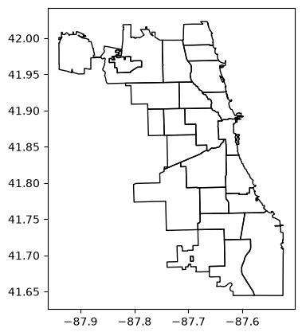

```python
police_districts.plot(figsize=(4,5), edgecolor='black', facecolor='none')
plt.show()
```

### Clean and geocode crime data

```python
def parse_location(loc):
    if pd.isna(loc):
        return (None, None)
    match = re.match(r"\(([-\d.]+),\s*([-\d.]+)\)", loc)
    if match:
        lat, lon = match.groups()
        return float(lat), float(lon)
    return (None, None)

crimes_chicago[['Latitude_clean', 'Longitude_clean']] = crimes_chicago['Location'].apply(
    lambda x: pd.Series(parse_location(x))
)
```

```python
print("Location column:", crimes_chicago['Location'].count())
print("Location column NAs:", crimes_chicago['Location'].isna().sum())
print(crimes_chicago[['Latitude_clean', 'Longitude_clean']].isna().sum())
```

```
Location column: 387481
Location column NAs: 1708
Latitude_clean     1708
Longitude_clean    1708
dtype: int64
```

```python
crimes_chicago = gpd.GeoDataFrame(
    crimes_chicago,
    geometry=gpd.points_from_xy(
        crimes_chicago["Longitude_clean"],
        crimes_chicago["Latitude_clean"]
    ),
    crs="EPSG:4326"
)
crimes_chicago = crimes_chicago[crimes_chicago.geometry.notna()]
```

```python
crimes_chicago = crimes_chicago.to_crs("EPSG:3435")
police_districts = police_districts.to_crs("EPSG:3435")
```

### Build the hex grid

The hex grid is built and clipped directly against the police district boundary. Merging those two steps removes the OSM dependency entirely and avoids building two separate grids.

```python
xmin, ymin, xmax, ymax = police_districts.total_bounds

# hexagon size in map units (feet); distance from hexagon center to each vertex
hex_size = 1500

dx = 3/2 * hex_size
dy = np.sqrt(3) * hex_size

hexagons = []
x = xmin
col = 0

while x <= xmax:
    y_offset = 0 if col % 2 == 0 else dy / 2
    y = ymin - dy
    while y <= ymax + dy:
        y_center = y + y_offset
        angles = np.arange(0, 360, 60)
        hexagon = Polygon([
            (x + hex_size * np.cos(np.radians(angle)),
             y_center + hex_size * np.sin(np.radians(angle)))
            for angle in angles
        ])
        hexagons.append(hexagon)
        y += dy
    x += dx
    col += 1

hex_grid = gpd.GeoDataFrame(geometry=hexagons, crs=police_districts.crs)

# keep hexagons that intersect the city, plus one ring of neighbours so edge hexagons
city_boundary = police_districts.union_all()
base_hexes = hex_grid[hex_grid.geometry.intersects(city_boundary)]
neighbour_hexes = hex_grid[hex_grid.geometry.touches(base_hexes.union_all())]
hex_grid = pd.concat([base_hexes, neighbour_hexes]).drop_duplicates().reset_index(drop=True)
```

### Join crimes to hexagons and compute density

```python
traveller_crime_types = [
    "THEFT",
    "ROBBERY",
    "MOTOR VEHICLE THEFT",
    "BURGLARY",
    "DECEPTIVE PRACTICE",
    "ASSAULT",
    "BATTERY"
]

# set to True later to test the indicator
USE_TRAVELLER_SUBSET = False

crime_subset = crimes_chicago[
    crimes_chicago["Primary Type"].isin(traveller_crime_types)
] if USE_TRAVELLER_SUBSET else crimes_chicago

crime_join = gpd.sjoin(
    crime_subset,
    hex_grid,
    how="left",
    predicate="within"
)

# exclude domestic incidents
non_domestic_join = crime_join[crime_join["Domestic"] != True]
crime_counts = non_domestic_join.groupby("index_right").size()

hex_grid["crime_count"] = crime_counts
hex_grid["crime_count"] = hex_grid["crime_count"].fillna(0)

hex_grid["area_m2"] = hex_grid.geometry.area
hex_grid["crime_density"] = (
    hex_grid["crime_count"] / hex_grid["area_m2"] * 1_000_000
)

# keep raw values (needed for most spatial-statistics tests) alongside a 0-1 scaled for later
scaler = MinMaxScaler()
hex_grid["crime_count_scaled"] = scaler.fit_transform(hex_grid[["crime_count"]])
hex_grid["crime_density_scaled"] = scaler.fit_transform(hex_grid[["crime_density"]])
```

### Plot

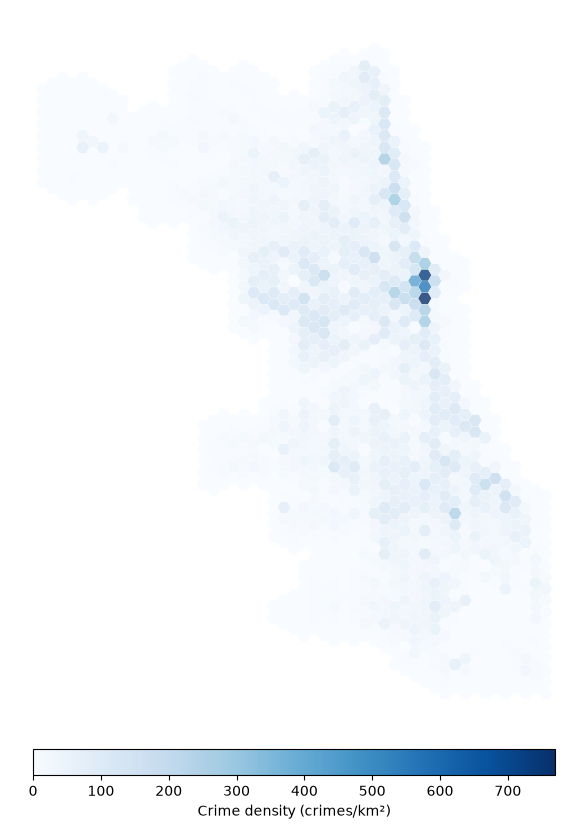

```python
fig, ax = plt.subplots(figsize=(9, 9))

hex_grid.plot(
    ax=ax,
    column="crime_density",
    cmap="Blues",
    linewidth=0.2,
    edgecolor="white",
    alpha=0.8,
    legend=True,
    legend_kwds={
        "label": "Crime density (crimes/km²)",
        "orientation": "horizontal",
        "location": "bottom",
        "shrink": 0.6,
        "pad": 0.02
    }
)
ax.set_axis_off()
plt.tight_layout()
plt.show()
```

### Quick sanity check

```python
print(hex_grid[["crime_count", "crime_density", "crime_count_scaled", "crime_density_scaled"]].describe())
```

```
       crime_count  crime_density  crime_count_scaled  crime_density_scaled
count  1478.000000    1478.000000         1478.000000           1478.000000
mean    211.962788      36.259784            0.047113              0.047113
std     315.393330      53.953311            0.070103              0.070103
min       0.000000       0.000000            0.000000              0.000000
25%       3.000000       0.513200            0.000667              0.000667
50%     112.000000      19.159476            0.024894              0.024894
75%     305.000000      52.175358            0.067793              0.067793
max    4499.000000     769.629292            1.000000              1.000000
```

## Statistical Checks for validation

### Spatial Autocorrelation: Moran's I:

Since the crime density map alone can't tell us whether the hotspots we see are actually meaningful or just visual noise, I ran a Global Moran's I test to check for spatial autocorrelation. The result was I = 0.61, against an expected value of about -0.0007 under complete spatial randomness, with a permutation-based p-value of 0.001 (999 permutations, so this is the smallest p-value that test could produce, none of the 999 random reshuffles of the data came anywhere close to reproducing this much clustering). This confirms that crime density across Chicago isn't randomly scattered; it's genuinely, statistically clustered rather than an artifact of how the hex grid happens to be drawn.

To see *where* that clustering actually is, I followed up with Local Moran's I (LISA), which classifies each hexagon by comparing its own value to its neighbours':

- 218 hexagons are High-High: statistically significant hotspots, where high-crime areas sit next to other high-crime areas.
- 478 hexagons are Low-Low: significant cold-spots, i.e. clusters of low crime.
- 14 hexagons (10 Low-High, 4 High-Low) are spatial outliers (isolated pockets that don't match their surroundings).
- The remaining 768 hexagons show no statistically significant clustering at all.

So out of 1,478 hexagons total, only the 218 High-High cells are the ones I can actually treat as validated hotspots, rather than just areas that happen to look dark on the density map. That's about 15% of the grid.  
For more information, see the code below.

### Getis-Ord Gi* Spatial Autocorrelation:

As a second, independent check on the crime density hotspots, I also ran Getis-Ord Gi*, which is the more widely known method for hot spot analysis and uses local sums of neighboring values rather than a local average, so it's built slightly differently from LISA even though it's answering a similar question.

Using binary contiguity weights (as is conventional for Gi*, since the statistic is based on the sum of neighboring values rather than a row-standardised average), the results came out as:

- 228 hexagons are significant Hot spots.
- 482 hexagons are significant Cold spots.
- 768 hexagons show no significant clustering.

These numbers line up closely with the LISA results from before, so I cross tabulated the two classifications directly to see how well they agree.

Out of 1,478 hexagons total, 1,462 (98.9%) received the same classification under both methods. All 218 LISA High-High hexagons were also classified as Hot spots by Gi*, and 477 of the 478 LISA Low-Low hexagons were also classified as Cold spots. Given that Moran's I and Getis-Ord Gi* are calculated in different ways, this level of agreement is a strong signal that the clustering I'm seeing is a real spatial pattern in the data rather than an artifact of one particular method.

The 16 hexagons that don't match up aren't really a disagreement between the two tests, they're a difference in what each test is actually measuring. The 4 hexagons that LISA flagged as High-Low outliers (a high crime hexagon sitting among low crime neighbors) were all classified as Cold spots by Gi*, because Gi* looks at the neighborhood as a whole rather than the individual hexagon, and the surrounding low crime values pull that local sum down. The same thing happens in reverse for the 10 Low-High hexagons, which were all classified as Hot spots by Gi* despite being a local dip within a high crime neighborhood. So rather than treating these 16 hexagons as noise, I'm treating them as a useful distinction: LISA is telling me which specific hexagon breaks the local pattern, while Gi* is telling me whether the neighborhood around it runs hot or cold overall.

Taken together, having two independently computed spatial statistics converge on the same 218 hotspot hexagons gives me a much stronger basis to call these areas statistically validated crime clusters, rather than relying on a single index or on how the map happens to look.

### Sensitivity Analysis of Arbitrary Hexagonal Size:

Moran's I is stable while the hotspot percentage is volatile. Moran's I stays within a narrow 0.524–0.610 range across a 4x span of hex sizes (750–3000 ft) with p-values hitting the 0.0001 floor every time. This proves my core claim that Chicago crime is spatially clustered is entirely robust and independent of cell size.

The hotspot percentage tells a different story. While 750, 1000, and 2000 ft cluster around 5.5–6.3%, 1500 ft jumps to 14.7% and 3000 ft jumps to 18.6%. Because this pattern is non-monotonic rather than a smooth upward trend, it signals a strong modifiable areal unit problem. Practically, my chosen 1500 ft grid shows roughly 1 in 7 hexagons as a hotspot, while a 2000 ft grid shows 1 in 16, creating a meaningful discrepancy for decision-making.

### Recency Weighting of Crime Statistics

To keep older incidents from dominating current risk patterns, an exponential decay function with a 180-day half-life was applied to weight crimes by recency. The resulting weight distribution is right-skewed with a mean of 0.389 and a median of 0.303, meaning most incidents sit past the half-life and receive lower weights. The decay math behaves as expected, scaling down from fresh incidents to a median weight of about 0.30 at 310 days and bottoming out around 0.10 for the oldest records at the 604-day mark.

A 180-day half-life is a fairly gentle decay over a 20-month span, meaning crimes from nearly a year and a half ago still contribute 10 percent of their original weight to the density surface. To make sure this choice does not arbitrarily bias the output, I should run a sensitivity check using tighter half-lives like 60 and 90 days to see how much Moran's I and the hotspot percentages actually move, using the same logic applied to the hexagon grid sizes.

- **Summing Up**: No matter what size grid cells I pick (from 750 to 3000 feet), the spatial math (Moran's I) proves that Chicago crime is genuinely clustered and definitely not random.  
  If I try to measure the exact percentage of the city that counts as a hotspot, the answer bounces around wildly depending on my grid size (from about 6 percent up to nearly 19 percent). That means I could not just pick one single number as an absolute fact.

### Moran's I Spatial Autocorrelation Code:

```python
w = Queen.from_dataframe(hex_grid, use_index=True)
w.transform = "r"  # row-standardise weights for Moran's I

moran = Moran(hex_grid["crime_density"], w)

print(f"Moran's I: {moran.I:.4f}")
print(f"Expected I under spatial randomness: {moran.EI:.4f}")
print(f"p-value (analytical, normality assumption): {moran.p_norm:.5f}")
print(f"p-value (permutation-based, {moran.permutations} permutations): {moran.p_sim:.5f}")
```

```
Moran's I: 0.6102
Expected I under spatial randomness: -0.0007
p-value (analytical, normality assumption): 0.00000
p-value (permutation-based, 999 permutations): 0.00100
```

```python
from esda.moran import Moran_Local

lisa = Moran_Local(hex_grid["crime_density"], w, permutations=9999, seed=42)

# quadrant: 1 = High-High, 2 = Low-High, 3 = Low-Low, 4 = High-Low
hex_grid["lisa_quadrant"] = lisa.q
hex_grid["lisa_p_sim"] = lisa.p_sim

# only trust clusters below a significance threshold
significance_level = 0.05
hex_grid["lisa_significant"] = hex_grid["lisa_p_sim"] < significance_level

quadrant_labels = {1: "High-High", 2: "Low-High", 3: "Low-Low", 4: "High-Low"}
hex_grid["lisa_label"] = hex_grid["lisa_quadrant"].map(quadrant_labels)
hex_grid.loc[~hex_grid["lisa_significant"], "lisa_label"] = "Not significant"

print(hex_grid["lisa_label"].value_counts())
```

```
lisa_label
Not significant    768
Low-Low            478
High-High          218
Low-High            10
High-Low             4
Name: count, dtype: int64
```

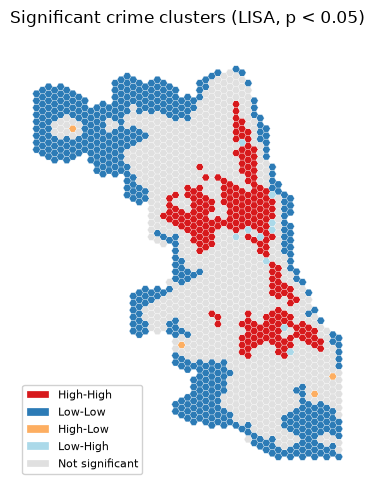

```python
fig, ax = plt.subplots(figsize=(5,5))

colors = {
    "High-High": "#d7191c",
    "Low-Low": "#2c7bb6",
    "High-Low": "#fdae61",
    "Low-High": "#abd9e9",
    "Not significant": "#e0e0e0",
}

for label, color in colors.items():
    subset = hex_grid[hex_grid["lisa_label"] == label]
    if len(subset) > 0:
        subset.plot(ax=ax, color=color, edgecolor="white", linewidth=0.2, label=label)

ax.set_axis_off()
ax.legend(loc="lower left", fontsize=8, framealpha=0.9)
ax.set_title(f"Significant crime clusters (LISA, p < {significance_level})")
plt.tight_layout()
plt.show()
```

### Getis-Ord Gi* Spatial Autocorrelation

```python
from esda.getisord import G_Local

# Getis-Ord Gi* conventionally uses binary weights, not row-standardized ones,
# since the statistic is built on the *sum* of neighboring values.
w_binary = Queen.from_dataframe(hex_grid, use_index=True)
w_binary.transform = "B"

gi_star = G_Local(hex_grid["crime_density"], w_binary, star=True, permutations=9999, seed=42)

hex_grid["gi_star_z"] = gi_star.Zs
hex_grid["gi_star_p_sim"] = gi_star.p_sim

significance_level = 0.05
hex_grid["gi_star_significant"] = hex_grid["gi_star_p_sim"] < significance_level

def classify_gi(row):
    if not row["gi_star_significant"]:
        return "Not significant"
    return "Hot spot" if row["gi_star_z"] > 0 else "Cold spot"

hex_grid["gi_star_label"] = hex_grid.apply(classify_gi, axis=1)
print(hex_grid["gi_star_label"].value_counts())
```

```
gi_star_label
Not significant    768
Cold spot          482
Hot spot           228
Name: count, dtype: int64
```

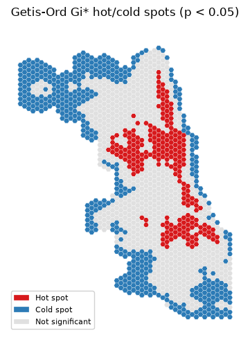

```python
fig, ax = plt.subplots(figsize=(5,5))

colors = {
    "Hot spot": "#d7191c",
    "Cold spot": "#2c7bb6",
    "Not significant": "#e0e0e0",
}

for label, color in colors.items():
    subset = hex_grid[hex_grid["gi_star_label"] == label]
    if len(subset) > 0:
        subset.plot(ax=ax, color=color, edgecolor="white", linewidth=0.2, label=label)

ax.set_axis_off()
ax.legend(loc="lower left", fontsize=8, framealpha=0.9)
ax.set_title(f"Getis-Ord Gi* hot/cold spots (p < {significance_level})")
plt.tight_layout()
plt.show()
```

### Comparison:

```python
comparison = pd.crosstab(hex_grid["lisa_label"], hex_grid["gi_star_label"])
print(comparison)
```

```
gi_star_label    Cold spot  Hot spot  Not significant
lisa_label
High-High                0       218                0
High-Low                 4         0                0
Low-High                 0        10                0
Low-Low                477         0                1
Not significant          1         0              767
```

### Sensitivity check on Hexagonal Sizes

The idea is to rebuild the pipeline across several hex sizes and see whether the clustering signals hold up of if they are severyl impacted by arbitrary hexagonal size

```python
def build_hex_grid(hex_size, boundary_gdf):
    """Build a pointy-top hex grid clipped to boundary_gdf, same logic as the main notebook."""
    xmin, ymin, xmax, ymax = boundary_gdf.total_bounds
    dx = 3/2 * hex_size
    dy = np.sqrt(3) * hex_size

    hexagons = []
    x = xmin
    col = 0
    while x <= xmax:
        y_offset = 0 if col % 2 == 0 else dy / 2
        y = ymin - dy
        while y <= ymax + dy:
            y_center = y + y_offset
            angles = np.arange(0, 360, 60)
            hexagon = Polygon([
                (x + hex_size * np.cos(np.radians(angle)),
                 y_center + hex_size * np.sin(np.radians(angle)))
                for angle in angles
            ])
            hexagons.append(hexagon)
            y += dy
        x += dx
        col += 1

    hex_grid = gpd.GeoDataFrame(geometry=hexagons, crs=boundary_gdf.crs)

    city_boundary = boundary_gdf.union_all()
    base_hexes = hex_grid[hex_grid.geometry.intersects(city_boundary)]
    neighbour_hexes = hex_grid[hex_grid.geometry.touches(base_hexes.union_all())]
    hex_grid = pd.concat([base_hexes, neighbour_hexes]).drop_duplicates().reset_index(drop=True)

    return hex_grid


def compute_crime_density(hex_grid, crimes_gdf):
    """Join crimes to a hex grid and compute raw (unscaled) crime density."""
    crime_join = gpd.sjoin(crimes_gdf, hex_grid, how="left", predicate="within")
    non_domestic_join = crime_join[crime_join["Domestic"] != True]
    crime_counts = non_domestic_join.groupby("index_right").size()

    hex_grid = hex_grid.copy()
    hex_grid["crime_count"] = crime_counts
    hex_grid["crime_count"] = hex_grid["crime_count"].fillna(0)
    hex_grid["area_m2"] = hex_grid.geometry.area
    hex_grid["crime_density"] = hex_grid["crime_count"] / hex_grid["area_m2"] * 1_000_000

    return hex_grid


def compute_weighted_crime_density(hex_grid, crimes_gdf, weight_col="recency_weight"):
    """Join crimes to a hex grid and compute a weighted crime density
    (e.g. recency-weighted, or later severity-weighted)."""
    crime_join = gpd.sjoin(crimes_gdf, hex_grid, how="left", predicate="within")
    non_domestic_join = crime_join[crime_join["Domestic"] != True]

    weighted_counts = non_domestic_join.groupby("index_right")[weight_col].sum()

    hex_grid = hex_grid.copy()
    hex_grid["crime_count"] = weighted_counts
    hex_grid["crime_count"] = hex_grid["crime_count"].fillna(0)
    hex_grid["area_m2"] = hex_grid.geometry.area
    hex_grid["crime_density"] = hex_grid["crime_count"] / hex_grid["area_m2"] * 1_000_000
    return hex_grid


def compute_spatial_stats(hex_grid, permutations=9999, seed=42):
    """Global Moran's I plus the share of hexagons that are significant LISA High-High hotspots."""
    w = Queen.from_dataframe(hex_grid, use_index=True)
    w.transform = "r"

    moran = Moran(hex_grid["crime_density"], w, permutations=permutations)

    lisa = Moran_Local(hex_grid["crime_density"], w, permutations=permutations, seed=seed)
    significant_high_high = ((lisa.q == 1) & (lisa.p_sim < 0.05)).sum()
    pct_high_high = significant_high_high / len(hex_grid) * 100

    return moran.I, moran.p_sim, pct_high_high
```

```python
hex_sizes_to_test = [750, 1000, 1500, 2000, 3000]

sensitivity_results = []

for size in hex_sizes_to_test:
    test_grid = build_hex_grid(size, police_districts)
    test_grid = compute_crime_density(test_grid, crimes_chicago)
    morans_i, p_sim, pct_high_high = compute_spatial_stats(test_grid)

    sensitivity_results.append({
        "hex_size_ft": size,
        "n_hexagons": len(test_grid),
        "mean_crime_density": test_grid["crime_density"].mean(),
        "morans_i": morans_i,
        "morans_p_sim": p_sim,
        "pct_significant_hotspot": pct_high_high,
    })
    print(f"hex_size={size} ft done: I={morans_i:.4f}, p_sim={p_sim:.5f}, "
          f"hotspot%={pct_high_high:.1f}, n_hexagons={len(test_grid)}")

sensitivity_df = pd.DataFrame(sensitivity_results)
```

```python
print(sensitivity_df)
```

```
   hex_size_ft  n_hexagons  mean_crime_density  morans_i  morans_p_sim  \
0          750        4835           44.343048  0.570637        0.0001
1         1000        2964           40.688001  0.574461        0.0001
2         1500        1478           36.259784  0.610190        0.0001
3         2000         751           40.146216  0.524434        0.0001
4         3000         452           29.645829  0.579843        0.0001

   pct_significant_hotspot
0                 5.460186
1                 6.039136
2                14.749662
3                 6.258322
4                18.584071
```

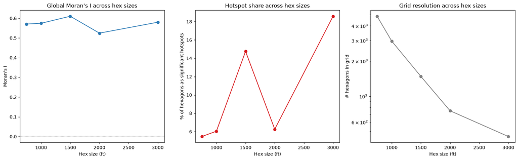

```python
fig, axes = plt.subplots(1, 3, figsize=(16, 5))

axes[0].plot(sensitivity_df["hex_size_ft"], sensitivity_df["morans_i"], marker="o", color="#2c7bb6")
axes[0].set_xlabel("Hex size (ft)")
axes[0].set_ylabel("Moran's I")
axes[0].set_title("Global Moran's I across hex sizes")
axes[0].axhline(0, color="grey", linewidth=0.5, linestyle="--")

axes[1].plot(sensitivity_df["hex_size_ft"], sensitivity_df["pct_significant_hotspot"], marker="o", color="#d7191c")
axes[1].set_xlabel("Hex size (ft)")
axes[1].set_ylabel("% of hexagons as significant hotspots")
axes[1].set_title("Hotspot share across hex sizes")

axes[2].plot(sensitivity_df["hex_size_ft"], sensitivity_df["n_hexagons"], marker="o", color="grey")
axes[2].set_xlabel("Hex size (ft)")
axes[2].set_ylabel("# hexagons in grid")
axes[2].set_title("Grid resolution across hex sizes")
axes[2].set_yscale("log")

plt.tight_layout()
plt.show()
```

```python
summary_table = sensitivity_df.copy()
summary_table["mean_crime_density"] = summary_table["mean_crime_density"].round(2)
summary_table["morans_i"] = summary_table["morans_i"].round(3)
summary_table["morans_p_sim"] = summary_table["morans_p_sim"].round(4)
summary_table["pct_significant_hotspot"] = summary_table["pct_significant_hotspot"].round(2)

summary_table = summary_table.rename(columns={
    "hex_size_ft": "Hex size (ft)",
    "n_hexagons": "# hexagons",
    "mean_crime_density": "Mean crime density",
    "morans_i": "Moran's I",
    "morans_p_sim": "p_sim",
    "pct_significant_hotspot": "% significant hotspot",})

display(summary_table)
```

|  | Hex size (ft) | # hexagons | Mean crime density | Moran's I | p_sim | % significant hotspot |
| --- | --- | --- | --- | --- | --- | --- |
| 0 | 750 | 4835 | 44.34 | 0.571 | 0.0001 | 5.46 |
| 1 | 1000 | 2964 | 40.69 | 0.574 | 0.0001 | 6.04 |
| 2 | 1500 | 1478 | 36.26 | 0.610 | 0.0001 | 14.75 |
| 3 | 2000 | 751 | 40.15 | 0.524 | 0.0001 | 6.26 |
| 4 | 3000 | 452 | 29.65 | 0.580 | 0.0001 | 18.58 |

```python
# do the hex sizes' I estimates actually differ from each other?
from scipy.stats import kruskal

n_bootstrap = 100
rng = np.random.default_rng(42)

bootstrap_results = []

for size in hex_sizes_to_test:
    """build the grid and weights matrix ONCE per hex size - neither depends on which crimes get resampled below, only on hex_size and the city boundary """
    test_grid = build_hex_grid(size, police_districts)
    w = Queen.from_dataframe(test_grid, use_index=True)
    w.transform = "r"

    for b in range(n_bootstrap):
        bootstrap_idx = rng.choice(len(crimes_chicago), size=len(crimes_chicago), replace=True)
        crime_sample = crimes_chicago.iloc[bootstrap_idx]

        density_grid = compute_crime_density(test_grid[["geometry"]].copy(), crime_sample)

        # permutations=0: only the point estimate I is needed here, not a p-value -
        # skipping the null simulation is what makes 500 iterations feasible at all
        moran_b = Moran(density_grid["crime_density"], w, permutations=0)
        bootstrap_results.append({"hex_size_ft": size, "bootstrap_i": moran_b.I})

    print(f"hex_size={size} ft: {n_bootstrap} bootstrap resamples done")

bootstrap_df = pd.DataFrame(bootstrap_results)
```

```python
fig, ax = plt.subplots(figsize=(6, 4))
bootstrap_df.boxplot(column="bootstrap_i", by="hex_size_ft", ax=ax)
ax.set_xlabel("Hex size (ft)")
ax.set_ylabel("Bootstrapped Moran's I")
ax.set_title("Spread of Moran's I across bootstrap resamples, by hex size")
plt.suptitle("")
plt.tight_layout()
plt.show()

groups = [bootstrap_df[bootstrap_df["hex_size_ft"] == s]["bootstrap_i"].values for s in hex_sizes_to_test]
stat, p_value = kruskal(*groups)
print(f"Kruskal-Wallis H = {stat:.3f}, p = {p_value:.6f}")
```

[output not shown]

### Temporal Window and Recency Weighting for the Crime Data

```python
# compute age
crimes_chicago["Date_parsed"] = pd.to_datetime(crimes_chicago["Date"], errors="coerce")

print("Unparseable dates:", crimes_chicago["Date_parsed"].isna().sum())
print("Earliest date:", crimes_chicago["Date_parsed"].min())
print("Latest date:", crimes_chicago["Date_parsed"].max())

# Use the most recent crime in the data as the reference point
reference_date = crimes_chicago["Date_parsed"].max()
crimes_chicago["age_days"] = (reference_date - crimes_chicago["Date_parsed"]).dt.days
```

[output not shown]

```python
# Option 1: only keep crimes from the last N days
window_days = 365

crimes_windowed = crimes_chicago[
    (crimes_chicago["age_days"] >= 0) & (crimes_chicago["age_days"] <= window_days)
].copy()

print(f"Full dataset: {len(crimes_chicago)} crimes")
print(f"Last {window_days} days: {len(crimes_windowed)} crimes "
      f"({len(crimes_windowed) / len(crimes_chicago) * 100:.1f}% of total)")
```

```
Full dataset: 389189 crimes
Last 365 days: 232140 crimes (59.6% of total)
```

```python
# Option 2: recency weighting
half_life_days = 180  # a crime 180 days old counts half as much as one from today

crimes_chicago["recency_weight"] = crimes_chicago["age_days"].apply(
    lambda d: 0.5 ** (d / half_life_days) if pd.notna(d) and d >= 0 else 0.0
)
```

```python
print(crimes_chicago[["age_days", "recency_weight"]].describe())
```

```
            age_days  recency_weight
count  389189.000000   389189.000000
mean      301.570080        0.389126
std       174.251624        0.252733
min         0.000000        0.097696
25%       146.000000        0.176777
50%       310.000000        0.303082
75%       450.000000        0.569943
max       604.000000        1.000000
```

### Conclusion

```python
def classify_validation(row):
    if row["lisa_label"] == "High-High" and row["gi_star_label"] == "Hot spot":
        return "Confirmed hotspot"
    elif row["lisa_label"] == "Low-Low" and row["gi_star_label"] == "Cold spot":
        return "Confirmed coldspot"
    elif row["lisa_label"] == "Not significant" and row["gi_star_label"] == "Not significant":
        return "Not significant"
    else:
        return "Partial / methods disagree"

hex_grid["validation_status"] = hex_grid.apply(classify_validation, axis=1)
print(hex_grid["validation_status"].value_counts())
```

```
validation_status
Not significant               767
Confirmed coldspot            477
Confirmed hotspot             218
Partial / methods disagree     16
Name: count, dtype: int64
```

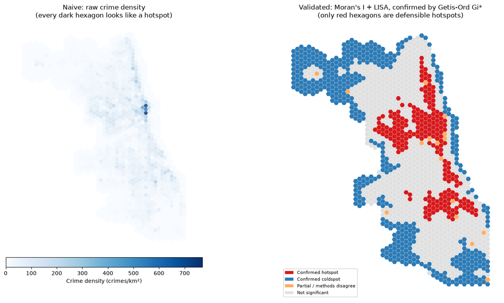

```python
fig, axes = plt.subplots(1, 2, figsize=(16, 8))

#panel 1, denisty plot
hex_grid.plot(
    ax=axes[0], column="crime_density", cmap="Blues",
    linewidth=0.2, edgecolor="white", alpha=0.8, legend=True,
    legend_kwds={"label": "Crime density (crimes/km²)", "orientation": "horizontal",
                 "location": "bottom", "shrink": 0.6, "pad": 0.02}
)
axes[0].set_axis_off()
axes[0].set_title("Naive: raw crime density\n(every dark hexagon looks like a hotspot)")

#panel 2 with statistical diagnostics
status_colors = {
    "Confirmed hotspot": "#d7191c",
    "Confirmed coldspot": "#2c7bb6",
    "Partial / methods disagree": "#fdae61",
    "Not significant": "#e0e0e0",
}
for label, color in status_colors.items():
    subset = hex_grid[hex_grid["validation_status"] == label]
    if len(subset) > 0:
        subset.plot(ax=axes[1], color=color, edgecolor="white", linewidth=0.2, label=label)
axes[1].set_axis_off()
axes[1].legend(loc="lower left", fontsize=8, framealpha=0.9)
axes[1].set_title("Validated: Moran's I + LISA, confirmed by Getis-Ord Gi*\n(only red hexagons are defensible hotspots)")

plt.tight_layout()
plt.show()
```

```python
chicago_neighbourhoods = gpd.read_file("neighbourhood_map.geojson").to_crs(hex_grid.crs)

confirmed_hotspots = hex_grid[hex_grid["validation_status"] == "Confirmed hotspot"].copy()
confirmed_hotspots["geometry"] = confirmed_hotspots.geometry.centroid


hotspot_by_neighbourhood = gpd.sjoin(
    confirmed_hotspots, chicago_neighbourhoods, how="left", predicate="within"
)

top_neighbourhoods = (
    hotspot_by_neighbourhood.groupby("PRI_NEIGH")
    .size()
    .sort_values(ascending=False)
    .head(10)
)
print(top_neighbourhoods)
```

```
PRI_NEIGH
Garfield Park     14
Grand Crossing    14
Humboldt Park     13
South Shore       12
Austin            12
Englewood         11
Lake View          9
North Lawndale     9
West Loop          8
West Town          7
dtype: int64
```

```python
neighbourhood_counts = (
    hotspot_by_neighbourhood.groupby("PRI_NEIGH")
    .size()
    .rename("hotspot_hex_count")
    .reset_index()
)

neighbourhoods_with_counts = chicago_neighbourhoods.merge(
    neighbourhood_counts, on="PRI_NEIGH", how="left"
)
neighbourhoods_with_counts["hotspot_hex_count"] = neighbourhoods_with_counts["hotspot_hex_count"].fillna(0)
```

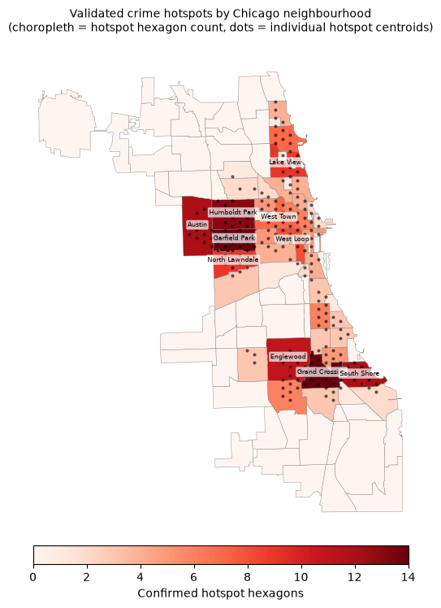

```python
fig, ax = plt.subplots(figsize=(8,8))

neighbourhoods_with_counts.plot(
    ax=ax,
    column="hotspot_hex_count",
    cmap="Reds",
    edgecolor="grey",
    linewidth=0.3,
    legend=True,
    legend_kwds={
        "label": "Confirmed hotspot hexagons",
        "orientation": "horizontal",
        "location": "bottom",
        "shrink": 0.6,
        "pad": 0.02
    }
)

# overlay the actual hotspot hexagon centroids on top
confirmed_hotspots.plot(ax=ax, color="black", markersize=4, alpha=0.5)

# label only the top 10 neighbourhoods by name
top_10_names = top_neighbourhoods_df.nlargest(10, "hotspot_hex_count")
for _, row in top_10_names.iterrows():
    geom = neighbourhoods_with_counts.loc[
        neighbourhoods_with_counts["PRI_NEIGH"] == row["neighbourhood"], "geometry"
    ].values[0]
    centroid = geom.centroid
    ax.annotate(
        row["neighbourhood"],
        xy=(centroid.x, centroid.y),
        ha="center", fontsize=6, color="black",
        bbox=dict(boxstyle="round,pad=0.2", fc="white", ec="none", alpha=0.7)
    )

ax.set_axis_off()
ax.set_title("Validated crime hotspots by Chicago neighbourhood\n(choropleth = hotspot hexagon count, dots = individual hotspot centroids)", fontsize =10)
plt.tight_layout()
plt.show()
```